# STAT 118: Notes Q

Working with text with `stringr`

Author

Affiliation

Violet Ross and Emily Malcolm-White

Middlebury College

[figure not shown]

artwork by @allisonhorst

# A few basics

**What is a string?**

- datatype we use to represent text
- use ” ”

**Examples of strings:**

- “Hello world”
- “5678”
- “blah blah blah”

** NOT a string:**

- 5678

# Using `stringr`

[`stringr`](https://stringr.tidyverse.org/) is a package containing a bunch of functions that help us work with strings. We’ll discuss how to detect, remove, extract, and count words/characters/phrases from a string. We’ll also talk about how to slice a string to get only the parts (aka the substrings) of it that you want.

[**`stringr` cheat sheet**](https://evoldyn.gitlab.io/evomics-2018/ref-sheets/R_strings.pdf)

`stringr` is contained within the `tidyverse` package.

```r
library(tidyverse)
```

**I’m registering for classes this Spring and am trying to decide what to take.** Let’s look at the course catalog!

Read in the courses data.

```r
courses <- read_csv("Fall23courses.csv")
```

## `str_detect`

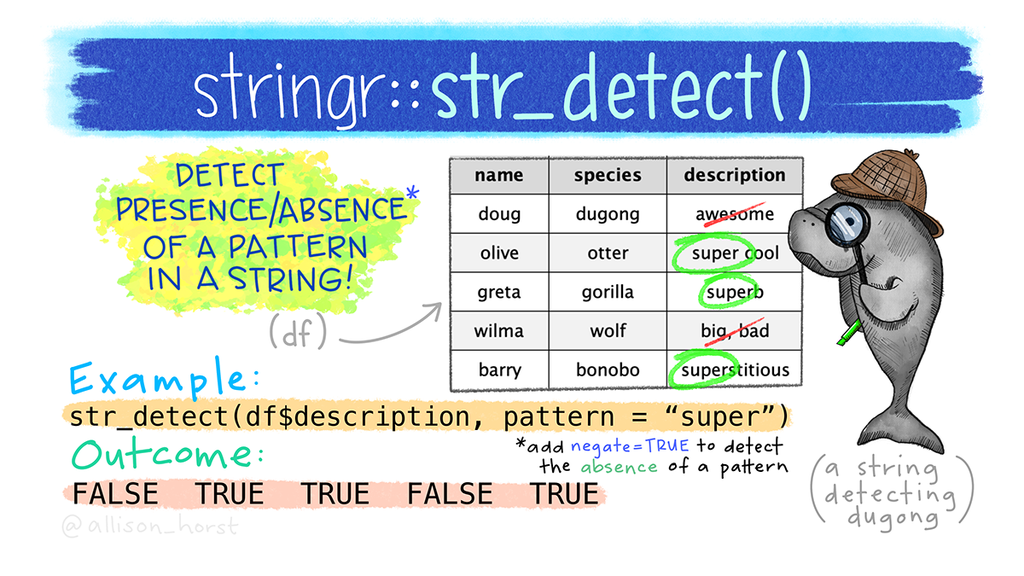

artwork by @allisonhorst

**inputs**: - string - pattern

**output**: - TRUE/FALSE

little example:

```r
str_detect("Welcome to data science, look at this cool data", "data")
```

```
[1] TRUE
```

```r
str_detect("Welcome to data science, look at this cool data", "pineapple")
```

```
[1] FALSE
```

I only want to take classes in Warner!

```r
courses %>%
  filter(str_detect(location, "WNS"))
```

```
# A tibble: 45 × 9
   titles      distros department time  location professor description courseNum
   <chr>       <chr>   <chr>      <chr> <chr>    <chr>     <chr>       <chr>
 1 Gothic and… AMR HI… Program i… 2:15… "Warner… Michael … "\nThis co… AMST0225…
 2 Education … AMR SOC Program i… 2:15… "Warner… Melissa … "\nWhat ar… BLST0115…
 3 Economic S… DED     Economics  2:15… "Warner… Amanda G… "\nAn intr… ECON0111…
 4 Introducto… SOC     Economics  9:45… "Warner… Raphaell… "\nAn intr… ECON0150…
 5 Introducto… SOC     Economics  11:1… "Warner… Raphaell… "\nAn intr… ECON0150…
 6 Introducto… SOC     Economics  8:15… "Warner… Will Pyle "\nAn intr… ECON0155…
 7 Introducto… SOC     Economics  9:45… "Warner… Will Pyle "\nAn intr… ECON0155…
 8 Microecono… <NA>    Economics  12:4… "Warner… <NA>      "\nMicroec… ECON0255…
 9 Microecono… <NA>    Economics  2:15… "Warner… <NA>      "\nMicroec… ECON0255…
10 Federal Re… AMR DED Economics  1:30… "Warner… Erin Wol… "\nIn this… ECON0360…
# ℹ 35 more rows
# ℹ 1 more variable: meet <chr>
```

Suppose I don’t want any classes on Friday. Let’s use `str_detect` to find our options.

```r
notFriday <- courses %>%
  filter(!str_detect(meet, "Friday"))
```

Perhaps I’m interested in immigration.

The `regex` function is used to write regular expressions in R. Regular expressions are helpful if you want to search for a pattern rather than a specific word or phrase.

For now, we will only use regex to ignore capitalization.

If you’re interested in using regular expressions at some point, this [regex cheat sheet](https://cheatography.com/davechild/cheat-sheets/regular-expressions/) will be super helpful.

```r
immigrationclasses <- courses %>%
  filter(str_detect(description, regex("immigration", ignore_case=TRUE)))

immigrationclasses
```

```
# A tibble: 10 × 9
   titles      distros department time  location professor description courseNum
   <chr>       <chr>   <chr>      <chr> <chr>    <chr>     <chr>       <chr>
 1 Immigrant … AMR HIS Program i… 11:1… "Axinn … Rachael … "\nIn this… AMST0175…
 2 Introducti… EUR LN… French     2:15… "Le Cha… William … "\nIn this… FREN0230…
 3 Introducti… CW EUR… French     2:15… "Le Cha… William … "\nIn this… FREN0230…
 4 The United… AMR HIS History    9:45… "Axinn … Joyce Mao "\nThis co… HIST0206…
 5 Introducti… CMP     Internati… 12:4… "Twilig… Amit Pra… "\nThis is… IGST0101…
 6 An Introdu… EUR LN… Italian    9:45… "Wright… Thomas V… "\nIntende… ITAL0251…
 7 An Introdu… EUR LN… Italian    11:1… "75 Sha… Sandra C… "\nIntende… ITAL0251…
 8 Globalizat… SOC     Political… 2:15… "Librar… Orion Le… "\nHow doe… PSCI0314…
 9 City Polit… <NA>    Political… 11:1… "LaForc… Bert Joh… "\nCities … PSCI0465…
10 Christiani… AMR HI… Religion   7:30… "Librar… James Ca… "\nReligio… RELI0398…
# ℹ 1 more variable: meet <chr>
```

## `str_extract` and `str_remove`

**str_extract inputs**: - string - pattern **str_extract output**: - the extracted pattern, if it appears in the the string

**str_remove inputs**: - string - pattern **str_extract output**: - the string without the pattern, if it appears in the string

little example:

```r
str_extract("Welcome to data science, look at this cool data", "data")
```

```
[1] "data"
```

```r
str_extract_all("Welcome to data science, look at this cool data", "data")
```

```
[[1]]
[1] "data" "data"
```

```r
str_remove("Welcome to data science, look at this cool data", "data")
```

```
[1] "Welcome to  science, look at this cool data"
```

```r
str_remove_all("Welcome to data science, look at this cool data", "data")
```

```
[1] "Welcome to  science, look at this cool "
```

CW is part of the distribution requirement column. I want CW to be its own column.

```r
courses %>%
  mutate(CW = str_extract(distros, "CW")) %>%
  mutate(distros = str_remove(distros, "CW"))
```

```
# A tibble: 586 × 10
   titles      distros department time  location professor description courseNum
   <chr>       <chr>   <chr>      <chr> <chr>    <chr>     <chr>       <chr>
 1 Introducti… AMR CMP Program i… 12:4… "Axinn … Roberto … "\nIn this… AMST0101…
 2 Immigrant … AMR HIS Program i… 11:1… "Axinn … Rachael … "\nIn this… AMST0175…
 3 American L… AMR LIT Program i… 11:1… "Axinn … Ellery F… "\nA study… AMST0209…
 4 Introducti… AMR HI… Program i… 1:30… "Twilig… Roberto … "\nIn this… AMST0213…
 5 Gothic and… AMR HI… Program i… 2:15… "Warner… Michael … "\nThis co… AMST0225…
 6 American C… AMR HIS Program i… 9:45… "Axinn … Holly Al… "\nFor man… AMST0234…
 7 Constructi… AMR ART Program i… 1:30… "Ross C… Deb Evans "\n“Democr… AMST0251…
 8 African Am… AMR LIT Program i… 9:45… "Axinn … William … "\nThis co… AMST0252…
 9 American D… AMR HI… Program i… 11:1… "Axinn … Susan Bu… "\nIn this… AMST0260…
10 Chicagoland AMR HIS Program i… 11:1… "Giffor… Jim Ralp… "\nIn this… AMST0264…
# ℹ 576 more rows
# ℹ 2 more variables: meet <chr>, CW <chr>
```

## `str_sub`

**str_sub inputs**: - string  
- starting character - ending character **str_sub output**: - string with only the characters between the start and the end

little example:

```r
str_sub("Welcome to data science, look at this cool data", start=12, end=23)
```

```
[1] "data science"
```

Bounds are inclusive!

Maybe I only want 200 level math classes.

We call this a **substring**, hence the function `str_sub`.

```r
MathClasses <- courses %>%
  filter(department == "Mathematics") %>%
  mutate(level=str_sub(courseNum, start=6, end=6))

Math2Classes <- MathClasses %>%
  filter(level== "2")
```

## `str_count`

**str_count inputs**: - string  
- pattern **str_count output**: - a count of the number of times the pattern appears in the string

little example:

```r
str_count("Welcome to data science, look at this cool data", "data")
```

```
[1] 2
```

Maybe I only want my classes to meet twice a week.

```r
courses <- courses %>%
  mutate(dayCount = str_count(meet, "day"))

#what's the maximum number of days a week a class meets?
max(courses$dayCount)
```

```
[1] 5
```

```r
#what's the mean number of days?
mean(courses$dayCount)
```

```
[1] 2.187713
```

Let’s visualize this data.

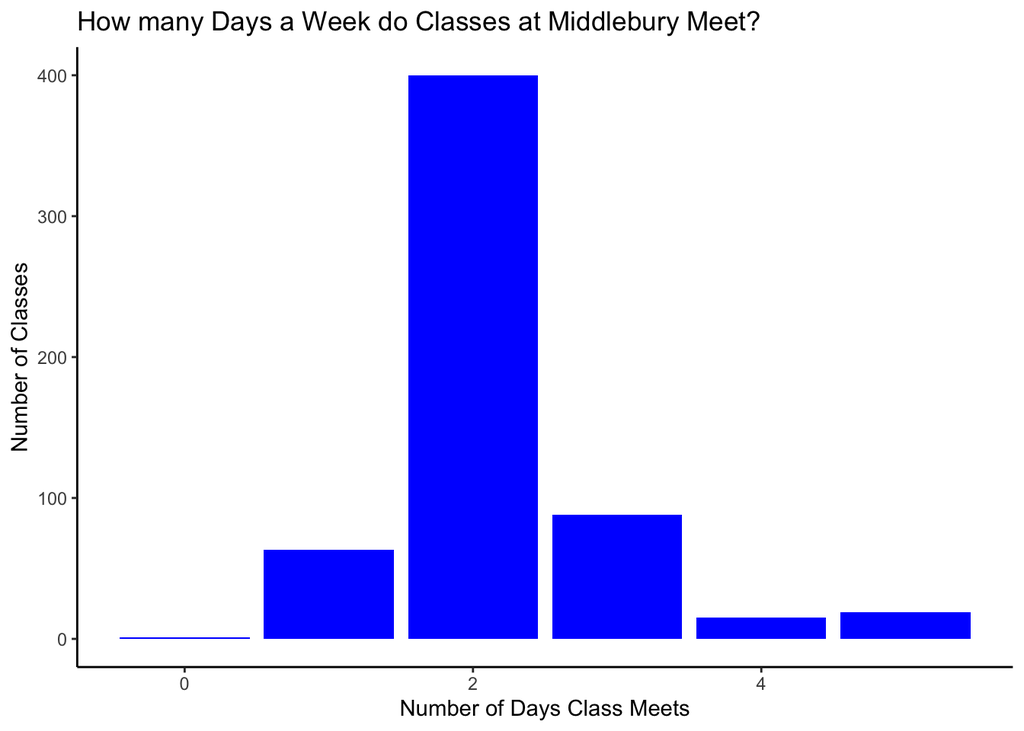

```r
courses %>%
  ggplot() +
  geom_bar(aes(x=dayCount), fill="blue") +
  xlab("Number of Days Class Meets") +
  ylab("Number of Classes") +
  labs(title="How many Days a Week do Classes at Middlebury Meet?")+
  theme_classic()
```

# Another useful function `str_squish`

`str_squish` is used to remove leading, trailing, and repeated interior whitespaces from strings

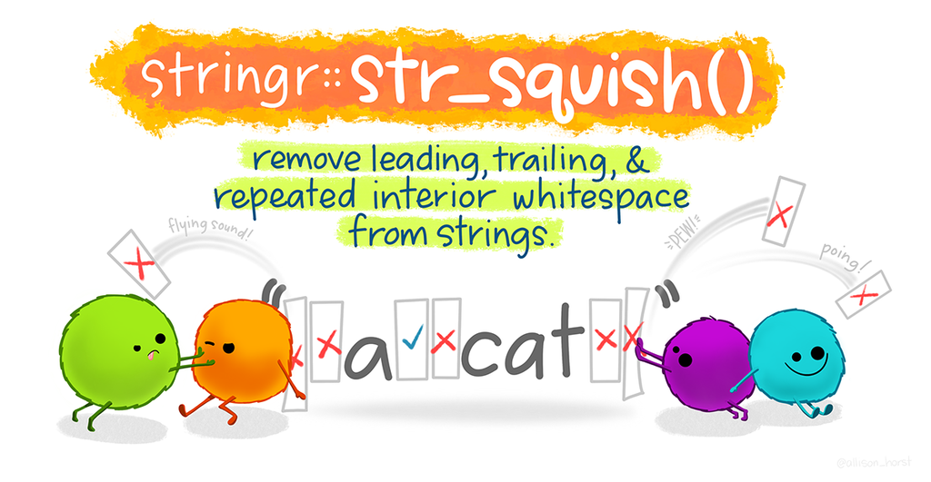

artwork by @allisonhorst